# Combining Dependent p-values

2026-06-29

Supplementary R code for reproducing the examples in the paper ``Combining Dependent p-values: Methods and Properties from a Practical Perspective’’ by Gasparin M., Goeman J.J., Heller R. and Solari A.

## Setup

Install (if necessary) and load the required R packages:

```r
require("pmerge") || install.packages("pmerge")
require("Iso") || install.packages("Iso")
require("tidyverse") || install.packages("tidyverse")
require("ggpubr") || install.packages("ggpubr")
require("grid") || install.packages("grid")
```

Load the score-free test statistic function:

```r
source("Tmax.R")
```

## Domain-Level Analysis of the Functional Observational Battery

The functional observational battery (FOB) is a biological screening assay consisting of $m=25$ endpoints grouped into six domains, each reflecting different aspects of neurological function, and is used to assess neurophysiological effects in animals following toxin exposure.

```r
# Load data
df <- read.table("E220RANK_Acute.csv",
                 header = TRUE,
                 sep = ",")

# Restrict to dose groups 0 and 1500 at time point 4
dat_raw <- df[
  df$DOSE_CODE %in% c(0, 1500) &
    df$TIME_OF_TESTING == 4,
  -c(1:2, 4, 33:38)
]

# Convert variables to numeric
dat_num <- data.frame(
  lapply(dat_raw, function(x) as.numeric(as.character(x))),
  check.names = FALSE
)

# Group endpoints by functional domain
endpoints_by_domain <- list(
  Autonomic = c(
    "LACRIMATION", "SALIVATION", "PALPEBRAL_CLOSURE",
    "PUPIL_RESPONSE", "URINATION", "DEFECATION"
  ),
  Activity = c(
    "REARS", "HOME_CAGE_POSTURE"
  ),
  Excitability = c(
    "EASE_OF_REMOVAL", "EASE_OF_HANDLING", "AROUSAL",
    "CLONIC_CONVULSIONS", "TONIC_CONVULSIONS"
  ),
  Neuromuscular = c(
    "GAIT_SCORE", "RIGHTING_REFLEX", "FORELIMB_GRIP",
    "HINDLIMB_GRIP", "FOOT_SPLAY"
  ),
  Sensorimotor = c(
    "TAIL_PINCH_RESPONSE", "CLICK_RESPONSE",
    "TOUCH_RESPONSE", "APPROACH_RESPONSE"
  ),
  Physiological_measures = c(
    "BODY_WEIGHT", "BODY_TEMPERATURE", "PILOERECTION"
  ),
  Other = c(
    "DOSE_CODE", "MOBILITY_SCORE", "VOCALIZATIONS",
    "PALPEBRAL_CLOSURE.1"
  )
)

# Select domains for analysis
domains_keep <- c(
  "Autonomic",
  "Activity",
  "Excitability",
  "Neuromuscular",
  "Sensorimotor",
  "Physiological_measures"
)

cols_keep <- c("DOSE_CODE", unlist(endpoints_by_domain[domains_keep]))
dat <- dat_num[, intersect(cols_keep, names(dat_num)), drop = FALSE]
```

For each endpoint, marginal counts of severity scores (1–4) for adverse effects observed are reported by exposure group (0 and 1.5g/kg). Endpoints are grouped into functional domains.

```r
n <- sum(dat$DOSE_CODE == 0)
N <- nrow(dat)
m <- ncol(dat) - 1
Z <- as.matrix(dat[, -1])
perms <- combn(1:N, n)
B <- ncol(perms)

# ---- Marginal counts (scores 1–4)

freq_fun <- function(x) {
  t(apply(x, 2, function(col)
    tabulate(factor(col, levels = 1:4), nbins = 4)))
}

g1 <- Z[1:8, ]
g2 <- Z[9:16, ]

f1 <- freq_fun(g1)
f2 <- freq_fun(g2)

mfreq <- cbind(f1, f2)
colnames(mfreq) <- c(1:4, 1:4)
rownames(mfreq) <- colnames(Z)

Tstat <- matrix(NA, nrow = B, ncol = m)

for (b in 1:B) {
  Zperm <- rbind(Z[perms[, b], ], Z[-perms[, b], ])
  Tstat[b, ] <- sapply(
    1:ncol(Zperm),
    function(i) Tmax(Zperm[1:n, i], Zperm[(n + 1):N, i])
  )
}

pval <- apply(Tstat, 2, function(t) mean(t >= t[1]))

data.frame(mfreq, pval)
```

```
#>                     X1 X2 X3 X4 X1.1 X2.1 X3.1 X4.1        pval
#> LACRIMATION          8  0  0  0    5    0    3    0 0.100000000
#> SALIVATION           8  0  0  0    8    0    0    0 1.000000000
#> PALPEBRAL_CLOSURE    8  0  0  0    7    1    0    0 0.500000000
#> PUPIL_RESPONSE       7  0  1  0    5    0    3    0 0.284615385
#> URINATION            4  3  1  0    6    1    1    0 0.861305361
#> DEFECATION           7  0  0  1    7    1    0    0 0.766666667
#> REARS                5  2  1  0    4    2    2    0 0.382517483
#> HOME_CAGE_POSTURE    8  0  0  0    7    0    1    0 0.500000000
#> EASE_OF_REMOVAL      0  8  0  0    0    7    1    0 0.500000000
#> EASE_OF_HANDLING     6  2  0  0    4    4    0    0 0.304195804
#> AROUSAL              4  3  1  0    3    0    3    2 0.052369852
#> CLONIC_CONVULSIONS   4  4  0  0    5    3    0    0 0.842657343
#> TONIC_CONVULSIONS    8  0  0  0    8    0    0    0 1.000000000
#> GAIT_SCORE           8  0  0  0    3    5    0    0 0.012820513
#> RIGHTING_REFLEX      8  0  0  0    5    2    1    0 0.100000000
#> FORELIMB_GRIP        5  2  1  0    2    1    0    5 0.013209013
#> HINDLIMB_GRIP        5  3  0  0    0    6    1    1 0.006526807
#> FOOT_SPLAY           6  1  1  0    6    1    1    0 0.838461538
#> TAIL_PINCH_RESPONSE  6  0  2  0    5    0    3    0 0.500000000
#> CLICK_RESPONSE       7  0  1  0    7    0    1    0 0.766666667
#> TOUCH_RESPONSE       8  0  0  0    6    0    0    2 0.233333333
#> APPROACH_RESPONSE    8  0  0  0    4    0    3    1 0.038461538
#> BODY_WEIGHT          6  1  1  0    4    2    0    2 0.176923077
#> BODY_TEMPERATURE     6  1  1  0    4    3    0    1 0.317249417
#> PILOERECTION         8  0  0  0    8    0    0    0 1.000000000
```

Domain-wise combined $p$-values.

```r
# ---- Domain-wise combination
domains <- endpoints_by_domain[-length(endpoints_by_domain)]
domains$All <- 1:25
domains <- c(tail(domains, 1), head(domains, -1))

comb_funs <- c("Bonferroni","Simes","Hommel+","Fisher","Average","Median","Cauchy","Harmonic")

res <- matrix(NA, nrow = length(domains), ncol = length(comb_funs) * 2)
colnames(res) <- c(comb_funs, paste0("U-",comb_funs))
rownames(res) <- paste(names(domains), " (",sapply(domains,length),")", sep="")

for (d in seq_along(domains)) {

  Zsel <- Z[, domains[[d]]]
  Tstat <- matrix(NA, nrow = B, ncol = ncol(Zsel))

  for (b in 1:B) {
    Zperm <- rbind(Zsel[perms[, b], ], Zsel[-perms[, b], ])
    Tstat[b, ] <- sapply(
      1:ncol(Zperm),
      function(i) Tmax(Zperm[1:n, i], Zperm[(n + 1):N, i])
    )
  }

  pval <- apply(Tstat, 2, function(t) mean(t >= t[1]))

  Pmat <- apply(Tstat, 2, function(t) {
    sapply(seq_along(t), function(i) mean(t >= t[i]))
  })

  # ---- Joint permutation p-values ----

  minP <- apply(Pmat, 1, min)
  res[d,1] <- mean(-minP >= -minP[1])

  SimesP <- apply(Pmat, 1, function(x) min(sort(x) * length(x)/(1:length(x))))
  res[d,2] <- mean(-SimesP >= -SimesP[1])

  HommelP <- apply(Pmat, 1, function(x) min(sort(x) * length(x)/(1:length(x))))
  res[d,3] <- mean(-HommelP >= -HommelP[1])

  FisherP <- apply(Pmat, 1, function(x) -sum(log(x)))
  res[d,4] <- mean(FisherP >= FisherP[1])

  AverageP <- rowMeans(Pmat)
  res[d,5] <- mean(-AverageP >= -AverageP[1])

  MedianP <- apply(Pmat, 1, function(x) sort(x)[ceiling(length(x)/2)])
  res[d,6] <- mean(-MedianP >= -MedianP[1])

  CauchyP <- apply(Pmat, 1, function(x) atan(mean(tan(pi*(x-1/2))) )/pi+1/2 )
  res[d,7] <- mean(-CauchyP >= -CauchyP[1])

  HarmonicP <- apply(Pmat, 1, function(x) mean(x^(-1))^(1/(-1)) )
  res[d,8] <- mean(-HarmonicP >= -HarmonicP[1])

  # ---- Marginal combination ----

  res[d,9]  <- min(1, min(pval) * length(pval))
  res[d,10] <- min(1, min(sort(pval) * length(pval)/(1:length(pval))))
  res[d,11] <- pSimes(pval, method = "G")
  res[d,12] <- pmean(pval, r = 0, dependence = "A")
  res[d,13] <- min(1, 2 * mean(pval))
  res[d,14] <- min(1, 2 * sort(pval)[ceiling(length(pval)/2)])
  res[d,15] <- NA
  res[d,16] <- ifelse(length(pval)>2, pharmonic(pval, method = "H2", censor = TRUE), NA )
}

res
```

```
#>                            Bonferroni       Simes     Hommel+       Fisher
#> All (25)                   0.03076923 0.024009324 0.024009324 0.0001554002
#> Autonomic (6)              0.18422688 0.201398601 0.201398601 0.1324786325
#> Activity (2)               0.38251748 0.284615385 0.284615385 0.2193473193
#> Excitability (5)           0.07614608 0.078088578 0.078088578 0.0786324786
#> Neuromuscular (5)          0.01181041 0.004584305 0.004584305 0.0003108003
#> Sensorimotor (4)           0.05058275 0.050582751 0.050582751 0.0268065268
#> Physiological_measures (3) 0.29984460 0.281895882 0.281895882 0.1393939394
#>                                Average       Median      Cauchy    Harmonic
#> All (25)                   0.001476301 0.0031857032 0.030147630 0.007381507
#> Autonomic (6)              0.140170940 0.3892773893 1.000000000 0.137373737
#> Activity (2)               0.151282051 0.3825174825 0.151282051 0.284615385
#> Excitability (5)           0.127505828 0.3059829060 1.000000000 0.082051282
#> Neuromuscular (5)          0.015073815 0.0003108003 0.002952603 0.003030303
#> Sensorimotor (4)           0.046386946 0.1986790987 0.023387723 0.032090132
#> Physiological_measures (3) 0.084459984 0.0920745921 1.000000000 0.201942502
#>                            U-Bonferroni    U-Simes  U-Hommel+  U-Fisher
#> All (25)                     0.16317016 0.11007511 0.31127199 0.6421881
#> Autonomic (6)                0.60000000 0.60000000 1.00000000 1.0000000
#> Activity (2)                 0.76503497 0.50000000 0.75000000 0.8746628
#> Excitability (5)             0.26184926 0.26184926 0.59788915 0.9918218
#> Neuromuscular (5)            0.03263403 0.02201502 0.04308654 0.1057924
#> Sensorimotor (4)             0.15384615 0.15384615 0.32051282 0.6437771
#> Physiological_measures (3)   0.53076923 0.47587413 0.87243590 0.9665033
#>                            U-Average   U-Median U-Cauchy U-Harmonic
#> All (25)                   0.8878384 0.76503497       NA 0.32415664
#> Autonomic (6)              1.0000000 1.00000000       NA 1.00000000
#> Activity (2)               0.8825175 0.76503497       NA         NA
#> Excitability (5)           1.0000000 1.00000000       NA 0.59316018
#> Neuromuscular (5)          0.3884071 0.02641803       NA 0.04819397
#> Sensorimotor (4)           0.7692308 0.46666667       NA 0.31214079
#> Physiological_measures (3) 0.9961150 0.63449883       NA 0.74133883
```

## Simulation study

We consider the Gaussian location-shift model with equicorrelated covariance matrix. For each combination of sparsity level $k$ and correlation $\rho$, the signal strength $h$ is calibrated so that Simes’ test at level $\alpha=0.05$ attains target power $1-\beta = 0.7$. The following code computes the calibration matrix:

```r
source("find_h_Simes.R")

m <- 30
eps <- 1e-4
l <- 10

rhoVec <- seq(-1/(m - 1) + eps, 1 - eps, length.out = l)
sVec <- round(seq(1, m, length.out = min(m, l)))

nreps_h <- 1000
alpha <- 0.05
target_power <- 0.7
tol_power <- 0.001

set.seed(123)

h_mat <- matrix(
  NA_real_,
  length(sVec), length(rhoVec),
  dimnames = list(paste0("s=", sVec), paste0("rho=", round(rhoVec, 2)))
)

for (i in seq_along(rhoVec)) {
  rho <- rhoVec[i]
  Sigma <- matrix(rho, m, m); diag(Sigma) <- 1
  R <- chol(Sigma)

  for (j in seq_along(sVec)) {
    h_mat[j, i] <- find_h_for_target_power_vec(
      s = sVec[j], R = R, m = m,
      target_power = target_power,
      nreps_h = nreps_h,
      tol_power = tol_power,
      alpha = alpha
    )
  }
}

h_mat
```

```
#>      rho=-0.03  rho=0.08   rho=0.2  rho=0.31  rho=0.43  rho=0.54  rho=0.66
#> s=1   3.438477  3.385925  3.425000  3.387427  3.453748  3.451657  3.457324
#> s=4   8.770958  9.170044  9.555086 10.025000 10.171298 10.613266 11.045426
#> s=7  12.725000 13.441198 14.125000 15.214062 15.990186 16.850000 17.593553
#> s=11 17.074866 18.470342 20.103125 21.181250 22.655419 24.250000 26.051563
#> s=14 19.799900 21.758594 24.025196 26.206250 27.174997 28.800000 31.792459
#> s=17 22.400000 24.741107 26.899993 29.385938 32.224219 34.885903 37.634457
#> s=20 25.250446 27.608778 30.800000 33.600000 36.376563 40.403384 43.775367
#> s=24 27.900000 30.798035 34.234325 38.664819 42.101117 45.718750 50.963211
#> s=27 29.639097 33.346441 37.836737 40.799609 44.800000 50.365374 55.869687
#> s=30 31.600000 35.766028 40.800000 44.585938 49.931143 55.520094 60.800000
#>       rho=0.77 rho=0.88     rho=1
#> s=1   3.440227  3.50000  3.473609
#> s=4  11.600000 11.87479 11.891745
#> s=7  18.587085 20.06250 19.375000
#> s=11 27.696875 30.41250 28.689063
#> s=14 34.662538 36.59834 34.999997
#> s=17 40.000000 43.39296 41.073980
#> s=20 46.912332 50.43625 46.199976
#> s=24 54.933008 59.22881 54.385913
#> s=27 60.594897 64.92422 58.900000
#> s=30 66.879941 70.38750 65.788413
```

We next compare the empirical power of the combining methods under the Gaussian location-shift model using the calibrated values of $h$:

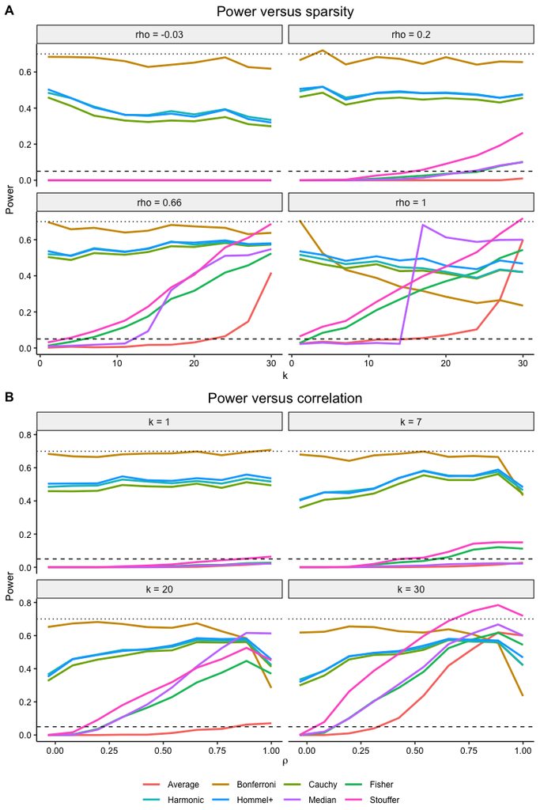

```r
nreps <- 1000

methods <- c("Average", "Bonferroni", "Cauchy", "Fisher",
             "Harmonic", "Hommel+", "Median", "Stouffer")

comb <- array(NA, c(nreps, length(sVec), length(rhoVec), length(methods)))
dimnames(comb)[[4]] <- methods

for (i in seq_along(rhoVec)) {
  rho <- rhoVec[i]
  Sigma <- matrix(rho, m, m); diag(Sigma) <- 1
  R <- chol(Sigma)

  for (j in seq_along(sVec)) {
    s <- sVec[j]
    theta <- numeric(m); theta[1:s] <- h_mat[j, i] / s

    X <- theta + t(R) %*% matrix(rnorm(m * nreps), m, nreps)
    P <- pnorm(X, lower.tail = FALSE)

    comb[, j, i, "Average"]    <- 2 * colMeans(P) < alpha
    comb[, j, i, "Bonferroni"] <- m * apply(P, 2, min) < alpha
    comb[, j, i, "Median"]     <- 2 * apply(P, 2, median) < alpha
    comb[, j, i, "Fisher"]     <- apply(P, 2, \(p) pmean(p, 0, "A", TRUE) < alpha)
    comb[, j, i, "Harmonic"]   <- apply(P, 2, \(p) pharmonic(p, "H2") < alpha)
    comb[, j, i, "Cauchy"]     <- apply(P, 2, \(p) pCauchy(p, "A", alpha)$Results[2] == "Reject")

    comb[, j, i, "Hommel+"] <- apply(P, 2, \(p) {
      H <- sum(1 / seq_len(m))
      sum((H * p <= alpha) / ceiling(m * H * p / alpha)) >= 1
    })

    comb[, j, i, "Stouffer"] <- colSums(qnorm(1 - P)) >= m * qnorm(1 - alpha)
  }
}

i_sel <- unique(round(c(1, length(rhoVec)/3, 2*length(rhoVec)/3, length(rhoVec))))
j_sel <- unique(round(c(1, length(sVec)/3, 2*length(sVec)/3, length(sVec))))

df_i <- map_dfr(i_sel, \(i)
  as.data.frame(apply(comb[, , i, ], c(2, 3), mean, na.rm = TRUE)) |>
    mutate(k = sVec, i = i) |>
    pivot_longer(all_of(methods), names_to = "Method", values_to = "Power")
)

df_j <- map_dfr(j_sel, \(j)
  as.data.frame(apply(comb[, j, , ], c(2, 3), mean, na.rm = TRUE)) |>
    mutate(rho = rhoVec, j = j) |>
    pivot_longer(all_of(methods), names_to = "Method", values_to = "Power")
)

df_i$Method <- factor(df_i$Method, levels = methods)
df_j$Method <- factor(df_j$Method, levels = methods)

base_theme <- theme_pubr(base_size = 12.5) +
  theme(
    plot.title = element_text(hjust = 0.5),
    legend.title = element_blank(),
    legend.text = element_text(size = 9),
    strip.text = element_text(size = 10.5),
    axis.title = element_text(size = 11),
    axis.text = element_text(size = 9.5),
    legend.spacing.x = unit(0.12, "cm"),
    legend.key.width = unit(0.8, "cm"),
    legend.key.height = unit(0.35, "cm")
  )

p1 <- ggplot(df_i, aes(k, Power, color = Method)) +
  geom_line(linewidth = 1) +
  geom_hline(yintercept = alpha, linetype = "dashed") +
  geom_hline(yintercept = target_power, linetype = "dotted") +
  facet_wrap(~ i, ncol = 2,
             labeller = labeller(i = \(x) paste0("rho = ", round(rhoVec[as.integer(x)], 2)))) +
  labs(x = "k", y = "Power", title = "Power versus sparsity") +
  guides(color = guide_legend(nrow = 2, byrow = TRUE)) +
  base_theme

p2 <- ggplot(df_j, aes(rho, Power, color = Method)) +
  geom_line(linewidth = 1) +
  geom_hline(yintercept = alpha, linetype = "dashed") +
  geom_hline(yintercept = target_power, linetype = "dotted") +
  facet_wrap(~ j, ncol = 2,
             labeller = labeller(j = \(x) paste0("k = ", sVec[as.integer(x)]))) +
  labs(x = expression(rho), y = "Power", title = "Power versus correlation") +
  guides(color = guide_legend(nrow = 2, byrow = TRUE)) +
  base_theme

p_all <- ggarrange(
  p1, p2,
  ncol = 1, nrow = 2,
  labels = c("A", "B"),
  common.legend = TRUE,
  legend = "bottom"
)

p_all
```